# Final Project

Author

Liam Dickson

# Final Project: *Riverdale* Season 1 Subtitle Analysis

## Loading Library Packages and Subtitles

```r
library(tidyverse)
library(stringr)
library(readr)
library(purrr)
library(tidytext)
#ChatGPT heavily consulted for creating combined dataset from srt files
subtitle_files <- list.files(
  path = "C:/Users/varsi/Desktop/Text as Data/Riverdale Subs",
  pattern = "\\.srt$",
  full.names = TRUE
)

subtitle_files
```

```
 [1] "C:/Users/varsi/Desktop/Text as Data/Riverdale Subs/Riverdale.S01E01.PROPER.FLEET.English-WWW.MY-SUBS.CO.srt"
 [2] "C:/Users/varsi/Desktop/Text as Data/Riverdale Subs/Riverdale.S01E02.PROPER.KILLERS.English-WWW.MY-SUBS.CO.srt"
 [3] "C:/Users/varsi/Desktop/Text as Data/Riverdale Subs/Riverdale.S01E03.PROPER.KILLERS.English-WWW.MY-SUBS.CO.srt"
 [4] "C:/Users/varsi/Desktop/Text as Data/Riverdale Subs/Riverdale.S01E04.SVA.English-WWW.MY-SUBS.CO.srt"
 [5] "C:/Users/varsi/Desktop/Text as Data/Riverdale Subs/Riverdale.S01E05.SVA.English-WWW.MY-SUBS.CO.srt"
 [6] "C:/Users/varsi/Desktop/Text as Data/Riverdale Subs/Riverdale.S01E06.SVA.English-WWW.MY-SUBS.CO.srt"
 [7] "C:/Users/varsi/Desktop/Text as Data/Riverdale Subs/Riverdale.S01E07.SVA.English-WWW.MY-SUBS.CO.srt"
 [8] "C:/Users/varsi/Desktop/Text as Data/Riverdale Subs/Riverdale.S01E08.SVA.English-WWW.MY-SUBS.CO.srt"
 [9] "C:/Users/varsi/Desktop/Text as Data/Riverdale Subs/Riverdale.S01E09.SVA.English-WWW.MY-SUBS.CO.srt"
[10] "C:/Users/varsi/Desktop/Text as Data/Riverdale Subs/Riverdale.S01E10.SVA.English-WWW.MY-SUBS.CO.srt"
[11] "C:/Users/varsi/Desktop/Text as Data/Riverdale Subs/Riverdale.S01E11.SVA.English-WWW.MY-SUBS.CO.srt"
[12] "C:/Users/varsi/Desktop/Text as Data/Riverdale Subs/Riverdale.S01E12.REPACK.SVA.English-WWW.MY-SUBS.CO.srt"
[13] "C:/Users/varsi/Desktop/Text as Data/Riverdale Subs/Riverdale.S01E13.SVA.English-WWW.MY-SUBS.CO.srt"
```

```r
time_to_seconds <- function(x) {
  h <- as.numeric(str_sub(x, 1, 2))
  m <- as.numeric(str_sub(x, 4, 5))
  s <- as.numeric(str_sub(x, 7, 8))
  ms <- as.numeric(str_sub(x, 10, 12))

  h * 3600 + m * 60 + s + ms / 1000
}

parse_srt <- function(file) {

  raw_text <- read_file(file)

  raw_text <- str_replace_all(raw_text, "\r\n", "\n")
  raw_text <- str_replace_all(raw_text, "\r", "\n")

  blocks <- str_split(raw_text, "\n\\s*\n")[[1]]

  episode_num <- str_extract(basename(file), "E\\d{2}") |>
    str_remove("E") |>
    as.integer()

  map_dfr(blocks, function(block) {
    lines <- str_split(block, "\n")[[1]] |> str_trim()
    lines <- lines[lines != ""]

    time_idx <- which(str_detect(lines, "-->"))[1]

    if (is.na(time_idx)) return(NULL)

    time_line <- lines[time_idx]
    times <- str_split(time_line, "\\s*-->\\s*")[[1]]

    if (length(times) != 2) return(NULL)

    text_lines <- lines[(time_idx + 1):length(lines)]

    if (length(text_lines) == 0) return(NULL)

    subtitle_text <- str_c(text_lines, collapse = " ")

    tibble(
      episode = episode_num,
      subtitle_id = suppressWarnings(as.integer(lines[1])),
      start_time = times[1],
      end_time = times[2],
      start_seconds = time_to_seconds(times[1]),
      end_seconds = time_to_seconds(times[2]),
      text = subtitle_text
    )
  }) |>
    mutate(
      file_name = basename(file),
      text = str_remove_all(text, "<[^>]+>"),
      text = str_squish(text)
    ) |>
    filter(text != "")
}

riverdale_subtitles <- map_dfr(subtitle_files, parse_srt)

glimpse(riverdale_subtitles)
```

```
Rows: 9,465
Columns: 8
$ episode       <int> 1, 1, 1, 1, 1, 1, 1, 1, 1, 1, 1, 1, 1, 1, 1, 1, 1, 1, 1,…
$ subtitle_id   <int> NA, 1, 2, 3, 4, 5, 6, 7, 8, 9, 10, 11, 12, 13, 14, 15, 1…
$ start_time    <chr> "00:00:00,000", "00:00:02,100", "00:00:05,761", "00:00:0…
$ end_time      <chr> "00:00:04,162", "00:00:05,736", "00:00:08,595", "00:00:1…
$ start_seconds <dbl> 0.000, 2.100, 5.761, 9.060, 11.476, 14.846, 16.048, 17.1…
$ end_seconds   <dbl> 4.162, 5.736, 8.595, 11.474, 14.844, 16.046, 17.180, 18.…
$ text          <chr> "WWW.MY-SUBS.COM", "Our story is about a town, a small t…
$ file_name     <chr> "Riverdale.S01E01.PROPER.FLEET.English-WWW.MY-SUBS.CO.sr…
```

```r
riverdale_subtitles |>
  count(episode)
```

```
# A tibble: 13 × 2
   episode     n
     <int> <int>
 1       1   845
 2       2   652
 3       3   705
 4       4   803
 5       5   628
 6       6   622
 7       7   749
 8       8   726
 9       9   851
10      10   754
11      11   794
12      12   667
13      13   669
```

```r
riverdale_subtitles |>
  select(episode, subtitle_id, start_time, end_time, text) |>
  print(n = 20)
```

```
# A tibble: 9,465 × 5
   episode subtitle_id start_time   end_time     text
     <int>       <int> <chr>        <chr>        <chr>
 1       1          NA 00:00:00,000 00:00:04,162 WWW.MY-SUBS.COM
 2       1           1 00:00:02,100 00:00:05,736 Our story is about a town, a s…
 3       1           2 00:00:05,761 00:00:08,595 and the people who live in the…
 4       1           3 00:00:09,060 00:00:11,474 From a distance, it presents i…
 5       1           4 00:00:11,476 00:00:14,844 like so many other small towns…
 6       1           5 00:00:14,846 00:00:16,046 Safe.
 7       1           6 00:00:16,048 00:00:17,180 Decent.
 8       1           7 00:00:17,182 00:00:18,682 Innocent.
 9       1           8 00:00:18,881 00:00:20,884 Get closer, though,
10       1           9 00:00:20,886 00:00:24,054 and you start seeing the shado…
11       1          10 00:00:24,856 00:00:28,058 The name of our town is Riverd…
12       1          11 00:00:38,587 00:00:40,670 And our story begins, I guess,
13       1          12 00:00:40,672 00:00:43,206 with what the Blossom twins di…
14       1          13 00:00:49,302 00:00:51,805 On the Fourth of July, just af…
15       1          14 00:00:51,830 00:00:54,417 Jason and Cheryl Blossom drove…
16       1          15 00:00:54,419 00:00:56,786 for an early morning boat ride.
17       1          16 00:00:57,226 00:00:58,625 Are you scared, Jason?
18       1          17 00:01:09,039 00:01:11,468 The next thing we know happene…
19       1          18 00:01:11,470 00:01:12,802 is that Dilton Doiley,
20       1          19 00:01:12,804 00:01:14,637 who was leading Riverdale's Bo…
# ℹ 9,445 more rows
```

```r
write_csv(riverdale_subtitles, "riverdale_season1_subtitles.csv")
```

## Project Intro

This project uses subtitle files from all 13 episodes of Riverdale Season 1 as a text corpus. The data were collected as .srt files, which contain the dialogue spoken in each episode along with timing information as well as file names. These files were parsed and combined into a single dataset in R, where each observation represents a single subtitle line. This structure allows the dataset to capture both the textual content and the temporal progression of dialogue and monologue across episodes.

The language in this corpus is conversational and narrative-driven, reflecting the dramatic tone of a television series. The series itself debuted in 2017, and holds a nostalgic sentiment for me as I originally watched the season back in middle school. The modern approach in writing style combined with a few interesting if not cringey lines makes me excited to work with this dataset because of the meaning it has for me personally. Unlike formal written text, this subtitle dialogue is often short, emotional, and context-dependent, which makes it particularly interesting for analysis. I am interested in media and storytelling, and subtitles provide a structured way to analyze how language and emotional tone evolve throughout a season. I am hopeful that this project could potentially serve as a foundation for a future line of work for myself. This project overall aims to analyze the dialogue of Riverdale Season 1 to uncover patterns in the narrative structure and emotional resonance of the show.

## Overarching Research Question

The central research question of this project is: How does emotional tone and language use change across episodes of *Riverdale* Season 1 and the season as a whole?

## Cleaning and Preprocessing Text

To prepare the subtitle data for analysis, several preprocessing steps were applied. First, all subtitle files were parsed and combined into a single dataset so that the full season could be analyzed together. During parsing, non-text elements such as timestamps and formatting were separated from the dialogue text,which allows me to focus language itself within the dataset.

Next, the text was cleaned by removing any remaining formatting tags, punctuation, and extra whitespace. All text was converted to lowercase to ensure consistency, so that words like “Betty” and “betty” would be treated as the same token. I decided to take these steps to standardize the text and reduce noise that could interfere with analysis.

After cleaning, the text was tokenized into individual words using R which I did some googling about to help with ideas for how to best organize this type of data. Tokenization was the first step, but many more organizational tasks can be completed to get different perspectives on this same data. I also decided to remove common stopwords such as “the,” “and,” and “is.” w These words appear frequently but carry little substantive meaning, so removing them helps highlight more meaningful vocabulary in the dataset.

Some preprocessing steps were deliberately omitted. For example, stemming and lemmatization were not applied, at least initially in this project, because they can make words less interpretable and harder to connect back to the original dialogue. I am debating coming back to more grammatical based data analysis later in the project, but that has yet to be decided. Additionally, character names were not removed, since they may be important for understanding narrative structure and recurring interactions. I wanted the preprocessing to preserve the integrity and identity of the show while also allowing for different insights and ideas.

Before preprocessing (raw subtitle line):

> “Betty, I don’t understand what you’re saying.”

After preprocessing and stopword removal:

> “betty dont understand youre saying”

```r
#Initial Cleaning
riverdale_subtitles_clean <- riverdale_subtitles |>
  mutate(
    text = str_to_lower(text),
    text = str_remove_all(text, "\\[.*?\\]"),
    text = str_remove_all(text, "\\(.*?\\)"),
    text = str_remove_all(text, "[[:punct:]]"),
    text = str_squish(text)
  )

riverdale_subtitles_clean |>
  select(episode, text) |>
  print(n = 10)
```

```
# A tibble: 9,465 × 2
   episode text
     <int> <chr>
 1       1 wwwmysubscom
 2       1 our story is about a town a small town
 3       1 and the people who live in the town
 4       1 from a distance it presents itself
 5       1 like so many other small towns all over the world
 6       1 safe
 7       1 decent
 8       1 innocent
 9       1 get closer though
10       1 and you start seeing the shadows underneath
# ℹ 9,455 more rows
```

```r
#Tokenizing text into individual words
riverdale_tokens <- riverdale_subtitles_clean |>
  unnest_tokens(word, text)

#Remove common stopwords
riverdale_tokens_nostop <- riverdale_tokens |>
  anti_join(stop_words, by = "word")

#Preview most common non-stopwords
riverdale_tokens_nostop |>
  count(word, sort = TRUE) |>
  print(n = 20)
```

```
# A tibble: 4,568 × 2
   word          n
   <chr>     <int>
 1 im          442
 2 dont        322
 3 dad         295
 4 youre       247
 5 betty       245
 6 jason       229
 7 archie      218
 8 mom         208
 9 yeah        191
10 polly       181
11 blossom     143
12 cheryl      134
13 didnt       134
14 hey         132
15 ill         125
16 gonna       113
17 veronica    111
18 jughead     110
19 riverdale   106
20 time        103
# ℹ 4,548 more rows
```

# Visualizations

To begin exploring the dataset, I created a visualization of the most common non-stopwords in the subtitle corpus. This frequency plot displays the words that appear most often across all episodes after preprocessing. By focusing on non-stopwords, the visualization highlights terms that are more meaningful to the content of the show rather than common filler words.

The first plot reveals which words dominate the dialogue in Riverdale Season 1 and provides an initial sense of recurring themes, character names, or topics. This type of visualization is useful as a first step because it show overall patterns about the show itself. I plan on diving deeper into episode specific and perhaps even word specific prominence as I know a lot of different and more specified visualizations and ideas can come from this initial graph.

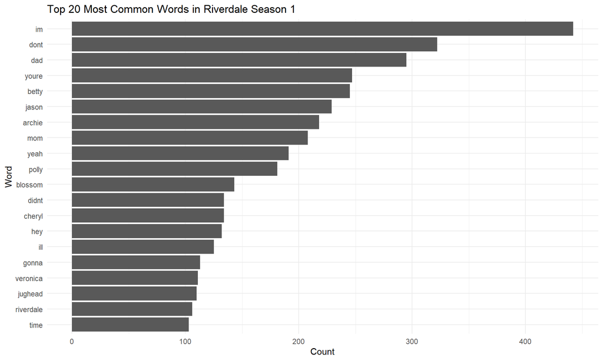

```r
#First Visualization: Most Common Non-Stopwords

word_counts <- riverdale_tokens_nostop |>
  count(word, sort = TRUE)

top_words <- word_counts |>
  slice_max(n, n = 20)

top_words |>
  ggplot(aes(x = reorder(word, n), y = n)) +
  geom_col() +
  coord_flip() +
  labs(
    title = "Top 20 Most Common Words in Riverdale Season 1",
    x = "Word",
    y = "Count"
  ) +
  theme_minimal()
```

## Plot 1

The first visualization shows the most common non-stopwords in the Riverdale Season 1 subtitle dataset. Many of these words reflect recurring dialogue patterns, character interactions, and central themes within the show. The results provide an initial overview of the language used throughout the season and confirm that the preprocessing steps were effective. This is a veru basic visualization that does not convey much meaning from the show. There are definitely some words included such as “im” and “dont” that do not add much substance to the visualization, but that will be addressed in the sentiment analysis.

## Method 1: Sentiment Analysis

```r
# Method 1: Sentiment Analysis

sentiment_data <- riverdale_tokens_nostop |>
  inner_join(get_sentiments("bing"), by = "word")

# Count sentiment words by episode
sentiment_by_episode <- sentiment_data |>
  count(episode, sentiment) |>
  pivot_wider(
    names_from = sentiment,
    values_from = n,
    values_fill = 0
  ) |>
  mutate(net_sentiment = positive - negative)

sentiment_by_episode
```

```
# A tibble: 13 × 4
   episode negative positive net_sentiment
     <int>    <int>    <int>         <int>
 1       1       91       91             0
 2       2      131       75           -56
 3       3      154       99           -55
 4       4      118       59           -59
 5       5      125       73           -52
 6       6      101       97            -4
 7       7      118       82           -36
 8       8      123       87           -36
 9       9      116      117             1
10      10      161       78           -83
11      11      130       89           -41
12      12      137       62           -75
13      13      119       81           -38
```

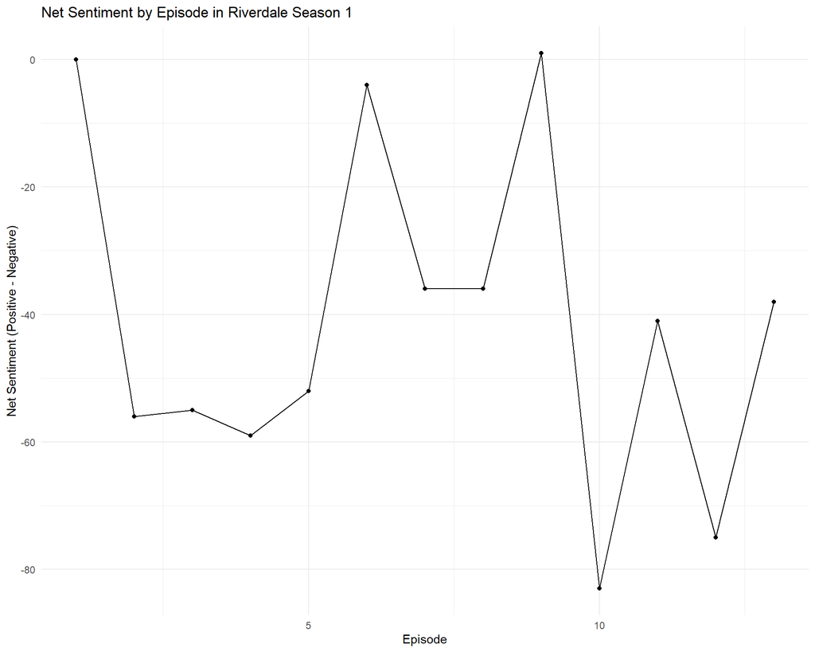

```r
# Sentiment visualization
sentiment_by_episode |>
  ggplot(aes(x = episode, y = net_sentiment)) +
  geom_line() +
  geom_point() +
  labs(
    title = "Net Sentiment by Episode in Riverdale Season 1",
    x = "Episode",
    y = "Net Sentiment (Positive - Negative)"
  ) +
  theme_minimal()
```

For the first analytical method, I used a dictionary-based sentiment analysis approach. Specifically, I applied the Bing sentiment lexicon to classify words in the subtitle dataset as either positive or negative. This method works by matching each word in the corpus to a predefined dictionary of sentiment words. To implement this method, I joined the tokenized dataset with the sentiment dictionary and then aggregated sentiment counts by episode. I calculated a net sentiment score for each episode by subtracting the number of negative words from the number of positive words. This allowed me to compare the overall emotional tone of each episode across the season. The results show variation in sentiment across episodes, with a large majority of the episodes having a negative sentiment. While this method provides a useful overview of emotional tone, it may not fully capture more complex aspects of dialogue such as sarcasm or context-dependent meaning.

## Method 2: TF-IDF

```r
#Method 2: TF-IDF Analysis

tfidf_episode <- riverdale_tokens_nostop |>
  count(episode, word, sort = TRUE) |>
  bind_tf_idf(word, episode, n) |>
  arrange(desc(tf_idf))

top_tfidf <- tfidf_episode |>
  group_by(episode) |>
  slice_max(tf_idf, n = 4) |>
  ungroup() |>
  arrange(episode, desc(tf_idf))

top_tfidf
```

```
# A tibble: 56 × 6
   episode word             n      tf   idf  tf_idf
     <int> <chr>        <int>   <dbl> <dbl>   <dbl>
 1       1 cheerleading     5 0.00292 2.56  0.00748
 2       1 fourth           4 0.00233 2.56  0.00598
 3       1 semiformal       4 0.00233 2.56  0.00598
 4       1 dance            9 0.00525 0.956 0.00501
 5       2 candy            4 0.00263 2.56  0.00675
 6       2 sugar            4 0.00263 2.56  0.00675
 7       2 moose            6 0.00395 1.47  0.00579
 8       2 gunshot          4 0.00263 1.87  0.00493
 9       3 chuck           21 0.0120  1.47  0.0175
10       3 gunshot          9 0.00513 1.87  0.00960
# ℹ 46 more rows
```

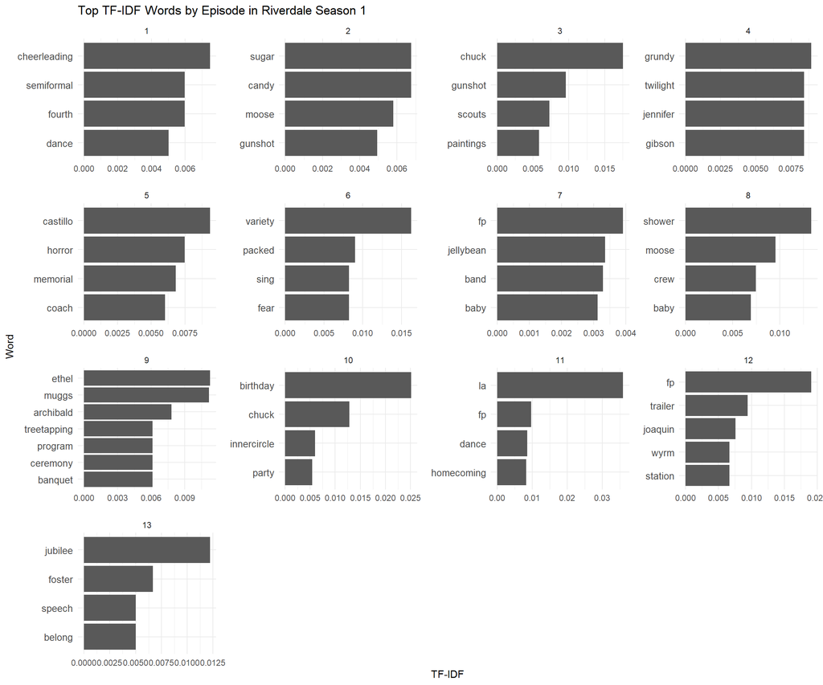

```r
#TF-IDF visualization
top_tfidf |>
  ggplot(aes(x = reorder_within(word, tf_idf, episode), y = tf_idf)) +
  geom_col() +
  coord_flip() +
  facet_wrap(~ episode, scales = "free", ncol = 4) +
  scale_x_reordered() +
  labs(
    title = "Top TF-IDF Words by Episode in Riverdale Season 1",
    x = "Word",
    y = "TF-IDF"
  ) +
  theme_minimal() +
  theme(
    panel.spacing = unit(1, "lines"),
    axis.text.y = element_text(size = 10)
  )
```

For the second analytical method, I used TF-IDF (term frequency-inverse document frequency), which is an unsupervised text analysis method that identifies words that are especially important within a specific document relative to the rest of the corpus. In this project, I treated each episode as a document and calculated TF-IDF scores for words within each episode.To implement this method, I counted word frequencies by episode and then used TF-IDF to identify words that are relatively distinctive to each episode rather than simply common across the entire season. I chose this method because it helps reveal episode-specific language and can highlight shifts in narrative focus over time.

## Comparison of Methods

The two analytical methods used in this project so far are dictionary-based sentiment analysis and TF-IDF analysis which both provide different but complementary insights into the subtitle data. The initial sentiment analysis focuses on measuring the emotional tone of the dialogue by classifying words as positive or negative, making it useful for identifying patterns in narrative intensity across episodes. In contrast, TF-IDF highlights words that are distinctive to specific episodes, allowing for a better understanding of how the language and themes of the show shift over time. In some ways TF-IDF provided more detailed and interpretable insights into the structure of the show, as it revealed episode-specific vocabulary and helped identify changes in narrative focus. There are still some repetition and words that do not make the most sense here, but the data definitely highlights important patterns and changhes. The sentiment analysis is still valuable for capturing broader emotional patterns and identifying episodes with higher levels of tension or negativity. These methods complement each other by providing both emotional and thematic perspectives on the data, and I hope to expand on both and potentially explore other methods as well.

# Episode Visualizations

## Plot 1 - Episode-by-Episode Sentiment Over Time

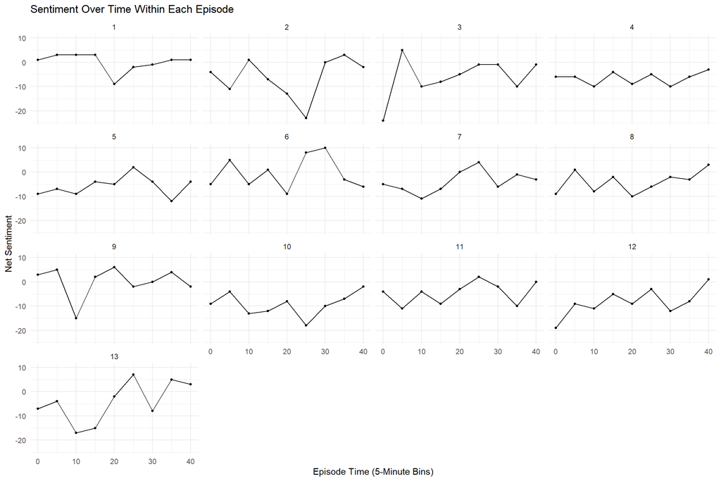

```r
sentiment_timeline <- riverdale_subtitles_clean |>
  mutate(
    time_bin = floor(start_seconds / 300) * 5
  ) |>
  unnest_tokens(word, text) |>
  anti_join(stop_words, by = "word") |>
  inner_join(get_sentiments("bing"), by = "word") |>
  mutate(sentiment_score = if_else(sentiment == "positive", 1, -1)) |>
  group_by(episode, time_bin) |>
  summarise(
    net_sentiment = sum(sentiment_score),
    .groups = "drop"
  )

sentiment_timeline |>
  ggplot(aes(x = time_bin, y = net_sentiment)) +
  geom_line() +
  geom_point(size = 1) +
  facet_wrap(~ episode, ncol = 4)+
  labs(
    title = "Sentiment Over Time Within Each Episode",
    x = "Episode Time (5-Minute Bins)",
    y = "Net Sentiment"
  ) +
  theme_minimal()
```

This visualization shows how sentiment changes over time within each episode, using five-minute time bins. Rather than reducing each episode to one overall sentiment score, this plot highlights emotional movement within episodes. This is useful because it connects the text analysis for episode specific dialogue more directly to narrative pacing and dramatic tension within each individual episode by itself.

The results reveal some clear differences between episodes. Episodes 10 and 12 maintain consistently negative sentiment for much of their runtime, which may indicate a heavier emotional tone and sustained tension. Episode 6 shifts strongly into positive sentiment during the middle and later sections of the episode, which might suggest a more emotionally balanced or uplifting progression. Episode 13, which serves as the season finale, begins with strongly negative sentiment before rebounding positively near the end, potentially reflecting narrative closure or emotional payoff. The visualization demonstrates that emotional tone changes dynamically within episodes and reinforces the idea that sentiment analysis can help capture patterns in television storytelling both from a narrative as a whole and with each episode as an individual microcosm.

## Plot 2 - Positive and Negative Language by Episode

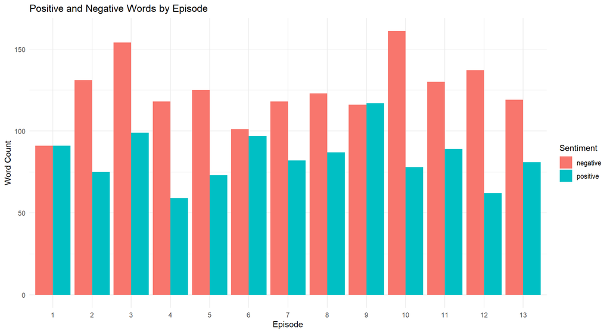

```r
sentiment_counts <- riverdale_tokens_nostop |>
  inner_join(get_sentiments("bing"), by = "word") |>
  count(episode, sentiment)

sentiment_counts |>
  ggplot(aes(x = factor(episode), y = n, fill = sentiment)) +
  geom_col(position = "dodge") +
  labs(
    title = "Positive and Negative Words by Episode",
    x = "Episode",
    y = "Word Count",
    fill = "Sentiment"
  ) +
  theme_minimal()
```

This visualization compares the number of positive and negative sentiment words used in each episode. Using the Bing sentiment lexicon, words from the subtitle dataset were classified as either positive or negative and then sorted by episode. Unlike the previous timeline visualization, which focused on changes in sentiment within episodes over time, this graph provides a broader comparison of overall emotional tone across the season.

The results show that nearly every episode contains more negative than positive language, reinforcing the dramatic and conflict-heavy nature of the show. Episodes 3 and 10 stand out as having especially high levels of negative sentiment, which may suggest that these episodes contain some of the most emotionally intense or tension-filled moments in the season. Episodes 1 and 9 appear more balanced between positive and negative language, which could indicate a less consistently negative tone. The visualization as a whole suggests that *Riverdale* Season 1 relies heavily on emotionally charged and negative dialogue to create consistent engagement for viewers throughout the season.

## Challenges

One of the main challenges in this project has been working with subtitle files, which are not naturally structured for text analysis. The .srt files required custom parsing in order to extract the dialogue and organize it into a usable dataset. This process involved separating text from timestamps and cleaning formatting artifacts, which was a lot different than the text data that I worked with so far. Another challenge is that subtitle lines are relatively short and often lack full context when analyzed individually. The shortness in length can make methods like sentiment analysis less precise, since the emotional meaning of a line may depend on surrounding dialogue. One unfortunate aspect of the dataset is that it does not consistently include speaker labels, which limits the ability to analyze dialogue at the character level. I am doing my best to work with different methods for sentiment analysis, but sentiment dictionaries may not fully capture nuances such as sarcasm or tone. Despite these challenges, I have still very much enjoyed the project so far and look forward to diving deeper into each episode.

## Conclusion and Future Directions

This project demonstrates how subtitle dialogue from a television series can be analyzed as a form of text data in order to uncover patterns in emotional tone, narrative structure, and thematic focus. Through preprocessing, sentiment analysis, TF-IDF analysis, and multiple visualizations, the project revealed that *Riverdale* Season 1 frequently relies on negative and emotionally intense language to maintain viewer engagement throughout the season. The analyses also showed that sentiment fluctuates significantly within episodes themselves, showcasing emotional pacing changes alongside major narrative moments and shifts in the storyline.

The episode-by-episode visualizations provided some of the most meaningful insights in the project because they highlighted how different episodes maintain distinct emotional and thematic identities. Certain episodes displayed consistently negative sentiment, while others showed stronger emotional recoveries or more balanced dialogue patterns. Similarly, the TF-IDF analysis demonstrated that each episode contains distinctive vocabulary tied to specific storylines, themes, or events occurring within that part of the season (even if those words still need more defined context to make sense).

If I decide to expand this project further in the future, one major direction would be to conduct deeper analyses of episodes individually rather than primarily at the season level. This could involve closely examining emotional arcs within specific episodes and identifying how dialogue patterns change during key narrative moments. In other words adding more relative context when analyzing episodes. Another important future direction would be exploring character-specific dialogue by attempting to isolate and manually label speaker identities from the show and subtitle data. This would make it possible to compare how different characters contribute to the emotional tone of the series and whether certain characters consistently use more positive, negative, or emotionally charged language.

This project illustrates how text-as-data methods can be applied to media and storytelling analysis in a meaningful way. By combining computational methods with narrative interpretation, the project provides a structured and engaging way for me to examine how television dialogue within Riverdale contributes to its overarching characteristics and narrative throughout the first season.

## Sources

- “Riverdale Subtitles.” [My-Subs](https://my-subs.co/showlistsubtitles-2094-riverdale). Accessed 27 March 2026.
- Weeks 2, 3, 9 R Labs
- Consulting Chat GPT